# Geospatial Analysis of the 2020 California Wildfires: Environmental Determinants and Implications

```r
# Convert Land_Cover_Type to numeric for proper merging
nlcd_poly$Land_Cover_Type <- as.numeric(nlcd_poly$Land_Cover_Type)

# Merge with land cover labels
nlcd_poly <- left_join(nlcd_poly, land_cover_labels, by = "Land_Cover_Type")

# Categorize land use for Developed vs. Natural/Other
nlcd_poly <- nlcd_poly %>%
  mutate(
    Land_Use_Category = ifelse(Land_Cover_Type %in% c(21,22,23,24),
                               "Developed (Urban/Populated)",
                               "Natural / Other")
  )

# Check if all labels joined correctly
if (!"Land_Cover_Name" %in% colnames(nlcd_poly)) {
  stop("Land_Cover_Name column is missing after merging labels.")
}
```

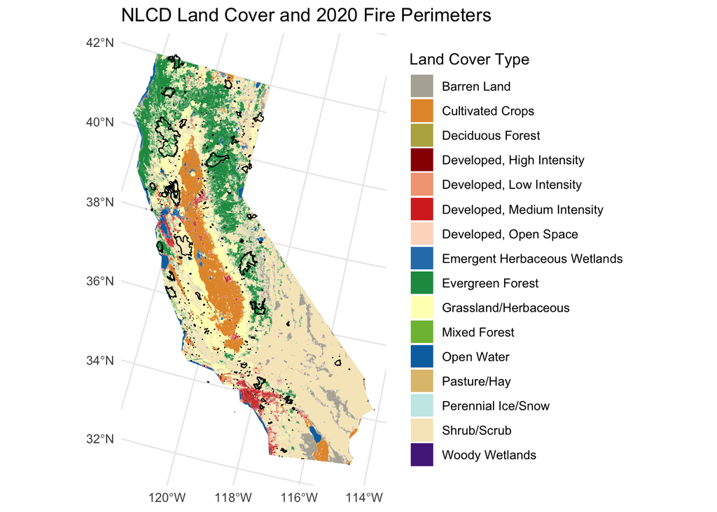

```r
# Plot using vectorized raster
ggplot() +
  geom_sf(data = nlcd_poly, aes(fill = factor(Land_Cover_Name)), color = NA) +
  geom_sf(data = st_transform(fire_perimeters, crs(nlcd_ca)), fill = NA, color = "black", linewidth = 0.3) +
  scale_fill_manual(values = c(
    "Barren Land" = "#b3afa4",               # Gray-tan for Barren Land
    "Cultivated Crops" = "#e49635",          # Orange
    "Deciduous Forest" = "#b8af4f",          # Olive-gold
    "Developed, High Intensity" = "#990000",  # Dark red
    "Developed, Low Intensity" = "#f2a582",   # Light orange-pink
    "Developed, Medium Intensity" = "#d73027", # Medium red
    "Developed, Open Space" = "#fddbc7",      # Very light pink
    "Emergent Herbaceous Wetlands" = "#2c7fb8", # Blue
    "Evergreen Forest" = "#1a9850",           # Deep green
    "Grassland/Herbaceous" = "#ffffbf",       # Light yellow
    "Mixed Forest" = "#7fbc41",               # Light green
    "Open Water" = "#0571b0",                 # Deep blue
    "Pasture/Hay" = "#dfc27d",                # Tan
    "Perennial Ice/Snow" = "#c7eae5",         # Very light blue
    "Shrub/Scrub" = "#f6e8c3",                # Light tan
    "Woody Wetlands" = "#542788"              # Purple for Woody Wetlands
  )) +
  labs(title = "NLCD Land Cover and 2020 Fire Perimeters",
       fill = "Land Cover Type") +
  theme_minimal()
```

This map clearly shows the relationship between California’s land cover types and 2020 fire perimeters. The black outlines mark fire boundaries, which appear **concentrated in evergreen forest** (dark green) and **grassland/herbaceous** areas (pale yellow).

Eastern California is dominated by shrub/scrub landscapes (cream color), while the Central Valley features a distinct band of cultivated cropland (orange). Urban development (red shades) is primarily concentrated along the southern coast, notably in the Los Angeles and San Diego regions. This visualization demonstrates how fires disproportionately affected forested regions in northern California and the Sierra Nevada range, while the central agricultural valley and eastern deserts experienced fewer fire events.

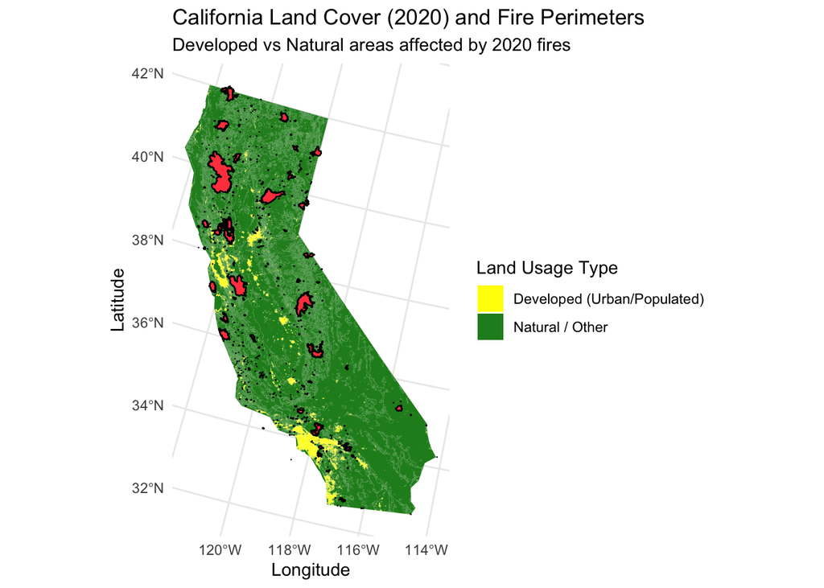

```r
# Plot with categorized land usage
ggplot() +
  geom_sf(data = nlcd_poly, aes(fill = Land_Use_Category), color = NA) +
  geom_sf(data = fire_perimeters, fill = "#FF474C", color = "black", linewidth = 0.4) +
  scale_fill_manual(values=c("yellow", "forestgreen"), name="Land Usage Type") +
  labs(title = "California Land Cover (2020) and Fire Perimeters",
       subtitle = "Developed vs Natural areas affected by 2020 fires",
       x = "Longitude", y = "Latitude") +
  theme_minimal()
```

## 7.3 Conclusion

This part analyzed the relationship between California’s 2020 wildfire perimeters and populated areas, creating a comprehensive **assessment of community risk exposure**. Through multiple visualizations, we explored how proximity to fires affected different communities and examined the geographical patterns of wildfire risk across diverse landscapes.

The most striking discovery was the **disproportionate population exposure to high wildfire risk**. While California’s complex landscape showed fires predominantly affecting forested regions, our population-weighted analysis revealed that over 27 million Californians lived in communities categorized as either “Extreme” or “High” risk. This included more than 1,100 distinct settlements, representing an alarming majority of the state’s population centers. The Central Valley’s agricultural corridor appeared to create a partial buffer zone, but many large population centers still fell within critical proximity to fire boundaries, highlighting the vast scale of vulnerability and challenging traditional assumptions about which communities face the greatest wildfire threats.

# 8 Project Summary

This project presented a comprehensive geospatial analysis of the 2020 California wildfires, examining how **environmental factors and human elements** influenced fire behavior during that record-setting season. It utilized satellite imagery, detailed fire perimeter data, and environmental measures such as temperature, drought conditions (via the SPEI index), and terrain features like elevation and slope to investigate the factors driving wildfire intensity, duration, and spread. The study also assessed the proximity of urban areas to active fire zones, thereby identifying the risks faced by communities in densely populated regions.

By integrating diverse datasets and applying advanced spatial analysis techniques, the project delineated **seasonal and regional patterns of wildfire occurrence** while highlighting the **complex interactions between fuel accumulation, weather conditions, and terrain challenges** that affected fire suppression efforts. These insights serve as **essential determinants** that should be taken into consideration when planning emergency response, urban development, and long-term land management, thereby providing a **data-driven framework** for understanding and mitigating wildfire risks in California.

The project acknowledges **several limitations** that do not weaken its overall contributions but point to areas for future improvement. For example, the temperature data only captured the maximum value on one day each month, which means we might have missed short-term shocks or daily extremes that could affect fire behavior. Similarly, the drought analysis used seasonal averages from the SPEI index, which may not fully capture sudden shifts in water availability or fuel moisture during important fire events.

In the case of elevation and slope, the data had to be averaged over large fire areas, so small-scale variations in the terrain might have been overlooked. Additionally, the fire brightness data was not complete, reducing the number of fires we could study for that particular factor.

Overall, these challenges are common in geospatial studies, and despite them, the project still offers a strong, data-driven framework for understanding and managing wildfire risks in California. Future projects could focus on additional variables that may have significant influence on wildfires such as wind speed, fire department expenditure, and temporal terrain analysis.

# 9 Data Sources

- UC Davis Report 2022 by Kat Kerlin. Accessed at: (https://www.ucdavis.edu/climate/news/californias-2020-wildfire-season-numbers)
- California Fire Perimeters Dataset. accessed at: (https://data.cnra.ca.gov/dataset/california-fire-perimeters-all)
- Administrative level 1 boundaries, which include states, provinces, and regions within countries from Natural Earth (scale 1:110)
- The US National Oceanic and Atmosphere Administration (NOAA) (https://www.noaa.gov/noaa-wildfire/wildfire-climate-connection)
- TIGER/Line Shapefiles, which are provided by the U.S. Census Bureau containing cities and towns in LA. accessed at: (https://www.census.gov/cgi-bin/geo/shapefiles/index.php?year=2020&layergroup=Places)
- Annuals NLCD Land Cover Data. Accessed at: (https://www.mrlc.gov/data?f%5B0%5D=category%3ALand%20Cover&f%5B1%5D=project_tax_term_term_parents_tax_term_name%3AAnnual%20NLCD)
- SPEI Index downloaded from the Global SPEI database at (https://spei.csic.es/database.html)
- Temperature data downloaded from (https://ftp.cpc.ncep.noaa.gov/GIS/GRADS_GIS/GeoTIFF/TEMP/us_tmax/)
- Wildfire data from NASA Fire Information for Resource Management System (FIRMS) data downloaded from (https://firms.modaps.eosdis.nasa.gov/map/#d:24hrs;@-32.5,1.9,3.0z)